# Lecture Notes (JSV) - Multivariate analysis - Data Analysis Wk2

Data Analysis Week - Session 2

Writer

Affiliation

Javier Silva-Valencia

Instituut Voor Tropische Geneeskunde. Antwerp-Belgium

Published

2023-02-28

Abstract

Today we are going to create an index/score. For this we have a lot of variables of socioeconomical aspects and we are going to clean and select the ones we are going to use to create the index/score

### Exercise 1

#### 0. Import CSV

0.1 Set working directory: We are not going to do it now, but this is useful to say to R that all the files we are going to work is that one directory.

0.2 Importing the CSV database under the name of Q1_B_106, with “,” as separator, and with “.” as decimal:

```r
Q1_B_106 <- read.csv("C:/Users/pined/OneDrive - Universidad Nacional Mayor de San Marcos/Javier 2022/Belgica/AC2_DataAnalysis_ThWk/Material/Q1_B_106.csv", sep=",", dec= ".")
```

#### 1. Cleaning the dataset

1.1 Seeing the structure of the dataset

```r
str(Q1_B_106)
```

```
'data.frame':   13377 obs. of  25 variables:
 $ FSN             : int  45001 45002 45003 45004 45005 45006 45007 45008 45009 45010 ...
 $ Radio           : int  1 1 -1 -1 -1 -1 -1 -1 -1 -1 ...
 $ CD_Player       : int  -1 -1 -1 -1 -1 -1 -1 -1 -1 -1 ...
 $ BW_Television   : int  -1 -1 -1 -1 -1 -1 -1 -1 -1 -1 ...
 $ Color_Television: int  -1 -1 -1 -1 -1 -1 -1 -1 -1 -1 ...
 $ Video_DVD_Player: int  -1 -1 -1 -1 -1 -1 -1 -1 -1 -1 ...
 $ Mobile          : int  -1 -1 -1 -1 -1 1 -1 -1 -1 -1 ...
 $ Non_Mobile_Phone: int  -1 -1 -1 -1 -1 -1 -1 -1 -1 -1 ...
 $ Refrigerator    : int  -1 -1 -1 -1 -1 -1 -1 -1 -1 -1 ...
 $ Iron            : int  -1 -1 -1 -1 -1 -1 -1 -1 -1 -1 ...
 $ Sewing_Machine  : int  -1 -1 -1 -1 -1 -1 -1 -1 -1 -1 ...
 $ Watch           : int  -1 -1 -1 -1 -1 1 -1 -1 -1 -1 ...
 $ Pressure_Cooker : int  -1 -1 -1 -1 -1 -1 -1 -1 -1 -1 ...
 $ Chairs          : int  1 -1 -1 -1 1 1 -1 -1 2 -1 ...
 $ Sofas           : int  -1 -1 -1 -1 -1 -1 -1 -1 -1 -1 ...
 $ Tables          : int  -1 -1 -1 -1 -1 1 -1 -1 -1 -1 ...
 $ Cot_Bed         : int  2 2 3 -1 2 1 2 1 2 -1 ...
 $ Cupboards       : int  -1 -1 -1 -1 -1 -1 -1 -1 -1 -1 ...
 $ Bicycle         : int  1 1 1 -1 -1 2 -1 -1 1 -1 ...
 $ Motor_Cycle     : int  -1 -1 -1 -1 -1 -1 -1 -1 -1 -1 ...
 $ Animal_Draw_Cart: int  -1 -1 -1 -1 -1 -1 -1 -1 -1 -1 ...
 $ Car             : int  -1 -1 -1 -1 -1 -1 -1 -1 -1 -1 ...
 $ Tractor         : int  -1 -1 -1 -1 -1 -1 -1 -1 -1 -1 ...
 $ Computer        : int  -1 -1 -1 -1 -1 -1 -1 -1 -1 -1 ...
 $ Electric_Fan    : int  -1 -1 -1 -1 -1 -1 -1 -1 -1 -1 ...
```

**Tip**

According to diccionary

-1 : Missing or not available

0, 1, 2, 3 : Number of items they have

```r
summary(Q1_B_106)
```

```
      FSN            Radio           CD_Player       BW_Television
 Min.   :45001   Min.   :-1.0000   Min.   :-1.0000   Min.   :-1.0000
 1st Qu.:48527   1st Qu.:-1.0000   1st Qu.:-1.0000   1st Qu.:-1.0000
 Median :52032   Median :-1.0000   Median :-1.0000   Median :-1.0000
 Mean   :52110   Mean   :-0.7555   Mean   :-0.9517   Mean   :-0.9015
 3rd Qu.:55671   3rd Qu.:-1.0000   3rd Qu.:-1.0000   3rd Qu.:-1.0000
 Max.   :59606   Max.   : 6.0000   Max.   : 3.0000   Max.   : 2.0000
 Color_Television  Video_DVD_Player      Mobile         Non_Mobile_Phone
 Min.   :-1.0000   Min.   :-1.0000   Min.   :-1.00000   Min.   :-1.0000
 1st Qu.:-1.0000   1st Qu.:-1.0000   1st Qu.:-1.00000   1st Qu.:-1.0000
 Median :-1.0000   Median :-1.0000   Median :-1.00000   Median :-1.0000
 Mean   :-0.9217   Mean   :-0.9785   Mean   : 0.01323   Mean   :-0.9885
 3rd Qu.:-1.0000   3rd Qu.:-1.0000   3rd Qu.: 1.00000   3rd Qu.:-1.0000
 Max.   : 2.0000   Max.   : 1.0000   Max.   :10.00000   Max.   : 1.0000
  Refrigerator          Iron         Sewing_Machine        Watch
 Min.   :-1.0000   Min.   :-1.0000   Min.   :-1.0000   Min.   :-1.0000
 1st Qu.:-1.0000   1st Qu.:-1.0000   1st Qu.:-1.0000   1st Qu.:-1.0000
 Median :-1.0000   Median :-1.0000   Median :-1.0000   Median :-1.0000
 Mean   :-0.9937   Mean   :-0.9415   Mean   :-0.8969   Mean   :-0.3998
 3rd Qu.:-1.0000   3rd Qu.:-1.0000   3rd Qu.:-1.0000   3rd Qu.: 1.0000
 Max.   : 1.0000   Max.   : 4.0000   Max.   : 3.0000   Max.   :12.0000
 Pressure_Cooker       Chairs            Sofas             Tables
 Min.   :-1.0000   Min.   :-1.0000   Min.   :-1.0000   Min.   :-1.0000
 1st Qu.:-1.0000   1st Qu.:-1.0000   1st Qu.:-1.0000   1st Qu.:-1.0000
 Median :-1.0000   Median :-1.0000   Median :-1.0000   Median :-1.0000
 Mean   :-0.8435   Mean   : 0.4572   Mean   :-0.9602   Mean   :-0.2501
 3rd Qu.:-1.0000   3rd Qu.: 2.0000   3rd Qu.:-1.0000   3rd Qu.: 1.0000
 Max.   : 5.0000   Max.   :40.0000   Max.   : 8.0000   Max.   :10.0000
    Cot_Bed         Cupboards          Bicycle          Motor_Cycle
 Min.   :-1.000   Min.   :-1.0000   Min.   :-1.00000   Min.   :-1.0000
 1st Qu.: 2.000   1st Qu.:-1.0000   1st Qu.:-1.00000   1st Qu.:-1.0000
 Median : 2.000   Median :-1.0000   Median : 1.00000   Median :-1.0000
 Mean   : 2.599   Mean   :-0.9624   Mean   : 0.09793   Mean   :-0.8656
 3rd Qu.: 3.000   3rd Qu.:-1.0000   3rd Qu.: 1.00000   3rd Qu.:-1.0000
 Max.   :24.000   Max.   : 7.0000   Max.   : 6.00000   Max.   : 5.0000
 Animal_Draw_Cart       Car             Tractor           Computer
 Min.   :-1.0000   Min.   :-1.0000   Min.   :-1.0000   Min.   :-1.0000
 1st Qu.:-1.0000   1st Qu.:-1.0000   1st Qu.:-1.0000   1st Qu.:-1.0000
 Median :-1.0000   Median :-1.0000   Median :-1.0000   Median :-1.0000
 Mean   :-0.9919   Mean   :-0.9938   Mean   :-0.9874   Mean   :-0.9982
 3rd Qu.:-1.0000   3rd Qu.:-1.0000   3rd Qu.:-1.0000   3rd Qu.:-1.0000
 Max.   : 1.0000   Max.   : 2.0000   Max.   : 3.0000   Max.   : 1.0000
  Electric_Fan
 Min.   :-1.0000
 1st Qu.:-1.0000
 Median :-1.0000
 Mean   :-0.6872
 3rd Qu.:-1.0000
 Max.   :11.0000
```

**Tip**

Example of what we can see: The maximum number of radios in a household is 6

#### 2. Replace values

2.1 We need that all ‘-1’ be converting to ‘0’

and all value more than ‘≥ 1’ be converting to ‘1’

```r
#We can do it by using "if else":
Q1_B_106$own_Radio <- ifelse(Q1_B_106$Radio>0,1,0)


#But other way is:
#Q1_B_106$own_Radio <- as.numeric(Q1_B_106$Radio > 0)
#Ask to create a variable called "own_Radio" only TRUE when "Radio" is more than 0 and converting that into a number (as.numeric) (1:true,0:false)


#Checking if it works
table(Q1_B_106$own_Radio, Q1_B_106$Radio, useNA = "always")
```

```
          -1     1     2     3     6  <NA>
  0    11753     0     0     0     0     0
  1        0  1608    12     3     1     0
  <NA>     0     0     0     0     0     0
```

```r
summary(Q1_B_106$own_Radio)
```

```
   Min. 1st Qu.  Median    Mean 3rd Qu.    Max.
 0.0000  0.0000  0.0000  0.1214  0.0000  1.0000
```

**Tip**

12.14% of households have at least one radio. When we only have 0 and 1, The mean is the proportion of individuals having the exposure.

We need to do that for every variable

```r
Q1_B_106$own_Radio <- ifelse(Q1_B_106$Radio>0,1,0)
Q1_B_106$own_CD_Player <- ifelse(Q1_B_106$CD_Player>0,1,0)
Q1_B_106$own_BW_Television <- ifelse(Q1_B_106$BW_Television>0,1,0)
Q1_B_106$own_Color_Television <- ifelse(Q1_B_106$Color_Television>0,1,0)
Q1_B_106$own_Video_DVD_Player <- ifelse(Q1_B_106$Video_DVD_Player>0,1,0)
Q1_B_106$own_Mobile <- ifelse(Q1_B_106$Mobile>0,1,0)
Q1_B_106$own_Non_Mobile_Phone <- ifelse(Q1_B_106$Non_Mobile_Phone>0,1,0)
Q1_B_106$own_Refrigerator <- ifelse(Q1_B_106$Refrigerator>0,1,0)
Q1_B_106$own_Iron <- ifelse(Q1_B_106$Iron>0,1,0)
Q1_B_106$own_Sewing_Machine <- ifelse(Q1_B_106$Sewing_Machine>0,1,0)
Q1_B_106$own_Watch <- ifelse(Q1_B_106$Watch>0,1,0)
Q1_B_106$own_Pressure_Cooker <- ifelse(Q1_B_106$Pressure_Cooker>0,1,0)
Q1_B_106$own_Chairs <- ifelse(Q1_B_106$Chairs>0,1,0)
Q1_B_106$own_Sofas <- ifelse(Q1_B_106$Sofas>0,1,0)
Q1_B_106$own_Tables <- ifelse(Q1_B_106$Tables>0,1,0)
Q1_B_106$own_Cot_Bed <- ifelse(Q1_B_106$Cot_Bed>0,1,0)
Q1_B_106$own_Cupboards <- ifelse(Q1_B_106$Cupboards>0,1,0)
Q1_B_106$own_Bicycle <- ifelse(Q1_B_106$Bicycle>0,1,0)
Q1_B_106$own_Motor_Cycle <- ifelse(Q1_B_106$Motor_Cycle>0,1,0)
Q1_B_106$own_Animal_Draw_Cart <- ifelse(Q1_B_106$Animal_Draw_Cart>0,1,0)
Q1_B_106$own_Car <- ifelse(Q1_B_106$Car>0,1,0)
Q1_B_106$own_Tractor <- ifelse(Q1_B_106$Tractor>0,1,0)
Q1_B_106$own_Computer <- ifelse(Q1_B_106$Computer>0,1,0)
Q1_B_106$own_Electric_Fan <- ifelse(Q1_B_106$Electric_Fan>0,1,0)
```

2.2 Now we will make a subset containing only the ‘own’ variables and FSN

```r
assets <- subset(Q1_B_106, select = grepl("own|FSN", names(Q1_B_106)))
str(assets)
```

```
'data.frame':   13377 obs. of  25 variables:
 $ FSN                 : int  45001 45002 45003 45004 45005 45006 45007 45008 45009 45010 ...
 $ own_Radio           : num  1 1 0 0 0 0 0 0 0 0 ...
 $ own_CD_Player       : num  0 0 0 0 0 0 0 0 0 0 ...
 $ own_BW_Television   : num  0 0 0 0 0 0 0 0 0 0 ...
 $ own_Color_Television: num  0 0 0 0 0 0 0 0 0 0 ...
 $ own_Video_DVD_Player: num  0 0 0 0 0 0 0 0 0 0 ...
 $ own_Mobile          : num  0 0 0 0 0 1 0 0 0 0 ...
 $ own_Non_Mobile_Phone: num  0 0 0 0 0 0 0 0 0 0 ...
 $ own_Refrigerator    : num  0 0 0 0 0 0 0 0 0 0 ...
 $ own_Iron            : num  0 0 0 0 0 0 0 0 0 0 ...
 $ own_Sewing_Machine  : num  0 0 0 0 0 0 0 0 0 0 ...
 $ own_Watch           : num  0 0 0 0 0 1 0 0 0 0 ...
 $ own_Pressure_Cooker : num  0 0 0 0 0 0 0 0 0 0 ...
 $ own_Chairs          : num  1 0 0 0 1 1 0 0 1 0 ...
 $ own_Sofas           : num  0 0 0 0 0 0 0 0 0 0 ...
 $ own_Tables          : num  0 0 0 0 0 1 0 0 0 0 ...
 $ own_Cot_Bed         : num  1 1 1 0 1 1 1 1 1 0 ...
 $ own_Cupboards       : num  0 0 0 0 0 0 0 0 0 0 ...
 $ own_Bicycle         : num  1 1 1 0 0 1 0 0 1 0 ...
 $ own_Motor_Cycle     : num  0 0 0 0 0 0 0 0 0 0 ...
 $ own_Animal_Draw_Cart: num  0 0 0 0 0 0 0 0 0 0 ...
 $ own_Car             : num  0 0 0 0 0 0 0 0 0 0 ...
 $ own_Tractor         : num  0 0 0 0 0 0 0 0 0 0 ...
 $ own_Computer        : num  0 0 0 0 0 0 0 0 0 0 ...
 $ own_Electric_Fan    : num  0 0 0 0 0 0 0 0 0 0 ...
```

2.3 Now we will focus only in those variables whose mean have a value between 5-95% (0.05-0.95)

why?: Because the mean is the proportion of individuals having the exposure, we are going to exclude the variables that nobody has (less than 5%) and the variables that all people has (more than 95%)

```r
#summary(assets)
round(sapply(assets, FUN=mean),3)   #To display the mean of each variable with 3 decimals
```

```
                 FSN            own_Radio        own_CD_Player
           52110.000                0.121                0.024
   own_BW_Television own_Color_Television own_Video_DVD_Player
               0.049                0.039                0.011
          own_Mobile own_Non_Mobile_Phone     own_Refrigerator
               0.476                0.006                0.003
            own_Iron   own_Sewing_Machine            own_Watch
               0.028                0.051                0.264
 own_Pressure_Cooker           own_Chairs            own_Sofas
               0.072                0.429                0.017
          own_Tables          own_Cot_Bed        own_Cupboards
               0.329                0.968                0.013
         own_Bicycle      own_Motor_Cycle own_Animal_Draw_Cart
               0.524                0.065                0.004
             own_Car          own_Tractor         own_Computer
               0.003                0.006                0.001
    own_Electric_Fan
               0.110
```

**Tip**

Besides FSN, 10 variables have a value between 5-95% (0.05-0.95)

2.3 We are going to create a new subset (assets2) with only in those variables whose mean have a value between 5-95% (0.05-0.95)

```r
assets2 <- subset(assets, select = c(FSN, own_Radio,own_Mobile, own_Sewing_Machine, own_Watch, own_Pressure_Cooker, own_Chairs, own_Tables, own_Bicycle, own_Motor_Cycle, own_Electric_Fan))
str(assets2)
```

```
'data.frame':   13377 obs. of  11 variables:
 $ FSN                : int  45001 45002 45003 45004 45005 45006 45007 45008 45009 45010 ...
 $ own_Radio          : num  1 1 0 0 0 0 0 0 0 0 ...
 $ own_Mobile         : num  0 0 0 0 0 1 0 0 0 0 ...
 $ own_Sewing_Machine : num  0 0 0 0 0 0 0 0 0 0 ...
 $ own_Watch          : num  0 0 0 0 0 1 0 0 0 0 ...
 $ own_Pressure_Cooker: num  0 0 0 0 0 0 0 0 0 0 ...
 $ own_Chairs         : num  1 0 0 0 1 1 0 0 1 0 ...
 $ own_Tables         : num  0 0 0 0 0 1 0 0 0 0 ...
 $ own_Bicycle        : num  1 1 1 0 0 1 0 0 1 0 ...
 $ own_Motor_Cycle    : num  0 0 0 0 0 0 0 0 0 0 ...
 $ own_Electric_Fan   : num  0 0 0 0 0 0 0 0 0 0 ...
```

#### 3. Adding animals variable

The researchers noticed that having a “bovines animals” variable is important, so we need to incorporate it. The only problem is that the animals information is in another dataset.

’own_bov’ for each household = whether or not it owns cows or buffaloes

```r
animals = readRDS("animals.RDS")
hlp1 <- subset(animals, select=c(FSN, count_Cow, count_Buf))
hlp1$own_bov <- NA
hlp1$own_bov[hlp1$count_Cow== 0 & hlp1$count_Buf==0] <- 0
hlp1$own_bov[hlp1$count_Cow> 0 | hlp1$count_Buf>0] <- 1
str(hlp1)
```

```
'data.frame':   7147 obs. of  4 variables:
 $ FSN      : int  45001 45002 45003 45004 45006 45009 45021 45024 45025 45027 ...
 $ count_Cow: int  NA NA 1 NA 2 NA 3 NA NA NA ...
 $ count_Buf: int  NA 1 NA NA NA NA NA NA NA NA ...
 $ own_bov  : num  NA 1 1 NA 1 NA 1 NA NA NA ...
```

#### 4. Adding brick wall variable

The researchers noticed that having a “brick_wall” variable is important, so we need to incorporate it. The only problem is that the brick_wall information is in another dataset.

4.1 Opening Q1_B dataset

```r
Q1_B <- read.csv("C:/Users/pined/OneDrive - Universidad Nacional Mayor de San Marcos/Javier 2022/Belgica/AC2_DataAnalysis_ThWk/Material/Q1_B.csv", sep=",", dec= ".")
```

4.2 Checking the variable Wall_Material in the Q1_B dataset

```r
table(Q1_B$Wall_Material)
```

```
   6  162  163  164  165  166
   4 4498  169 5791 2914    1
```

**Tip**

According the code list:

```
6= Other
163= Grass
163= Bamboo
164, 165, 166= Brick
```

4.3. I only need “FSN” and “WallMaterial” variables

```r
hlp2 <- subset(Q1_B, select = c(FSN, Wall_Material))
```

4.4 Creating a new variable called brickwall according to what I need

```r
hlp2$brick_wall <- NA
hlp2$brick_wall[hlp2$Wall_Material %in% c(6,162,163)] <- 0
hlp2$brick_wall[hlp2$Wall_Material %in% c(164:166)] <- 1

table(hlp2$brick_wall, Q1_B$Wall_Material)
```

```
       6  162  163  164  165  166
  0    4 4498  169    0    0    0
  1    0    0    0 5791 2914    1
```

#### 5. Merging datasets

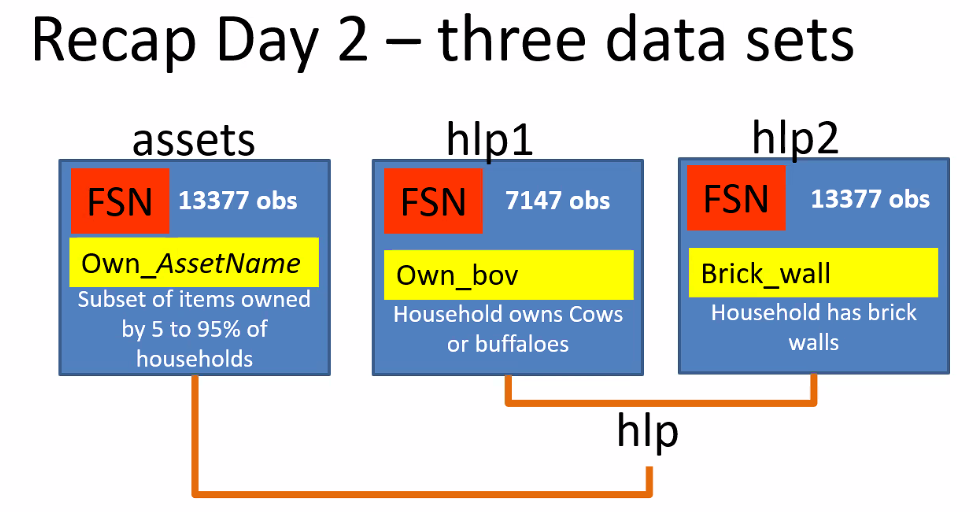

Merging planning

5.1 Merging hlp1 and hlp2

```r
str(hlp1)
```

```
'data.frame':   7147 obs. of  4 variables:
 $ FSN      : int  45001 45002 45003 45004 45006 45009 45021 45024 45025 45027 ...
 $ count_Cow: int  NA NA 1 NA 2 NA 3 NA NA NA ...
 $ count_Buf: int  NA 1 NA NA NA NA NA NA NA NA ...
 $ own_bov  : num  NA 1 1 NA 1 NA 1 NA NA NA ...
```

```r
str(hlp2)
```

```
'data.frame':   13377 obs. of  3 variables:
 $ FSN          : num  45001 45002 45003 45004 45005 ...
 $ Wall_Material: num  164 164 164 162 163 163 162 164 164 162 ...
 $ brick_wall   : num  1 1 1 0 0 0 0 1 1 0 ...
```

```r
hlp  <-  merge(hlp2, hlp1, all=TRUE, by = "FSN")
str(hlp)
```

```
'data.frame':   13377 obs. of  6 variables:
 $ FSN          : num  45001 45002 45003 45004 45005 ...
 $ Wall_Material: num  164 164 164 162 163 163 162 164 164 162 ...
 $ brick_wall   : num  1 1 1 0 0 0 0 1 1 0 ...
 $ count_Cow    : int  NA NA 1 NA NA 2 NA NA NA NA ...
 $ count_Buf    : int  NA 1 NA NA NA NA NA NA NA NA ...
 $ own_bov      : num  NA 1 1 NA NA 1 NA NA NA NA ...
```

```r
#View(hlp)
```

we Dont need countCow, count_Buf or Wall_Material

```r
hlp <- subset(hlp, select=-c(count_Cow,count_Buf,Wall_Material))
str(hlp)
```

```
'data.frame':   13377 obs. of  3 variables:
 $ FSN       : num  45001 45002 45003 45004 45005 ...
 $ brick_wall: num  1 1 1 0 0 0 0 1 1 0 ...
 $ own_bov   : num  NA 1 1 NA NA 1 NA NA NA NA ...
```

```r
str(hlp)
```

```
'data.frame':   13377 obs. of  3 variables:
 $ FSN       : num  45001 45002 45003 45004 45005 ...
 $ brick_wall: num  1 1 1 0 0 0 0 1 1 0 ...
 $ own_bov   : num  NA 1 1 NA NA 1 NA NA NA NA ...
```

```r
str(assets2)
```

```
'data.frame':   13377 obs. of  11 variables:
 $ FSN                : int  45001 45002 45003 45004 45005 45006 45007 45008 45009 45010 ...
 $ own_Radio          : num  1 1 0 0 0 0 0 0 0 0 ...
 $ own_Mobile         : num  0 0 0 0 0 1 0 0 0 0 ...
 $ own_Sewing_Machine : num  0 0 0 0 0 0 0 0 0 0 ...
 $ own_Watch          : num  0 0 0 0 0 1 0 0 0 0 ...
 $ own_Pressure_Cooker: num  0 0 0 0 0 0 0 0 0 0 ...
 $ own_Chairs         : num  1 0 0 0 1 1 0 0 1 0 ...
 $ own_Tables         : num  0 0 0 0 0 1 0 0 0 0 ...
 $ own_Bicycle        : num  1 1 1 0 0 1 0 0 1 0 ...
 $ own_Motor_Cycle    : num  0 0 0 0 0 0 0 0 0 0 ...
 $ own_Electric_Fan   : num  0 0 0 0 0 0 0 0 0 0 ...
```

```r
assets3  <-  merge(assets2, hlp, all=TRUE, by = "FSN")
str(assets3)
```

```
'data.frame':   13377 obs. of  13 variables:
 $ FSN                : int  45001 45002 45003 45004 45005 45006 45007 45008 45009 45010 ...
 $ own_Radio          : num  1 1 0 0 0 0 0 0 0 0 ...
 $ own_Mobile         : num  0 0 0 0 0 1 0 0 0 0 ...
 $ own_Sewing_Machine : num  0 0 0 0 0 0 0 0 0 0 ...
 $ own_Watch          : num  0 0 0 0 0 1 0 0 0 0 ...
 $ own_Pressure_Cooker: num  0 0 0 0 0 0 0 0 0 0 ...
 $ own_Chairs         : num  1 0 0 0 1 1 0 0 1 0 ...
 $ own_Tables         : num  0 0 0 0 0 1 0 0 0 0 ...
 $ own_Bicycle        : num  1 1 1 0 0 1 0 0 1 0 ...
 $ own_Motor_Cycle    : num  0 0 0 0 0 0 0 0 0 0 ...
 $ own_Electric_Fan   : num  0 0 0 0 0 0 0 0 0 0 ...
 $ brick_wall         : num  1 1 1 0 0 0 0 1 1 0 ...
 $ own_bov            : num  NA 1 1 NA NA 1 NA NA NA NA ...
```

```r
#View(assets3)
```

5.3 Check NA values

The merging creates NA values (ex: in own_bov), but that values are because that household doesnt have a bovine animal, so it should be 0

Checking NA

```r
table (assets3$own_bov)
```

```
   0    1
   1 4331
```

```r
table (assets3$own_bov, useNA = "ifany")
```

```
   0    1 <NA>
   1 4331 9045
```

```r
table (assets3$own_bov, useNA = "always")
```

```
   0    1 <NA>
   1 4331 9045
```

```r
str(assets3)
```

```
'data.frame':   13377 obs. of  13 variables:
 $ FSN                : int  45001 45002 45003 45004 45005 45006 45007 45008 45009 45010 ...
 $ own_Radio          : num  1 1 0 0 0 0 0 0 0 0 ...
 $ own_Mobile         : num  0 0 0 0 0 1 0 0 0 0 ...
 $ own_Sewing_Machine : num  0 0 0 0 0 0 0 0 0 0 ...
 $ own_Watch          : num  0 0 0 0 0 1 0 0 0 0 ...
 $ own_Pressure_Cooker: num  0 0 0 0 0 0 0 0 0 0 ...
 $ own_Chairs         : num  1 0 0 0 1 1 0 0 1 0 ...
 $ own_Tables         : num  0 0 0 0 0 1 0 0 0 0 ...
 $ own_Bicycle        : num  1 1 1 0 0 1 0 0 1 0 ...
 $ own_Motor_Cycle    : num  0 0 0 0 0 0 0 0 0 0 ...
 $ own_Electric_Fan   : num  0 0 0 0 0 0 0 0 0 0 ...
 $ brick_wall         : num  1 1 1 0 0 0 0 1 1 0 ...
 $ own_bov            : num  NA 1 1 NA NA 1 NA NA NA NA ...
```

5.4 Replacing NA

```r
assets3$own_bov[is.na(assets3$own_bov)]<- 0
#View(assets3)
table (assets3$own_bov, useNA = "always")
```

```
   0    1 <NA>
9046 4331    0
```

#### 6. Principle component analysis

**What is a Principle component analysis (PCA)?**

*Principal Component Analysis (PCA)* is a statistical technique that is used to transform a large number of variables into a smaller number (or just 1) new variable. Is often used for making scores or index.

When we do a score/index we tend to put equal weight to every variable because we think that every variable is equal important. But is that true? Usually no. So in *Principle component analysis* we try to put a weight to every variable depending the variance. It is useful to also put in in order to know which first component we need to work. (Which variables are representatives and in what measure)

The idea behind PCA is to find the underlying patterns in the data using its variances. The analysis will create a first (principal) component, then a second, third, and so on. Each component captures a different aspect of the variation in the data, with the first component capturing the most variation, and subsequent components capturing progressively less.

Usually we use the first component and with that then create a weighted variable for each individual.

```r
names(assets3)
```

```
 [1] "FSN"                 "own_Radio"           "own_Mobile"
 [4] "own_Sewing_Machine"  "own_Watch"           "own_Pressure_Cooker"
 [7] "own_Chairs"          "own_Tables"          "own_Bicycle"
[10] "own_Motor_Cycle"     "own_Electric_Fan"    "brick_wall"
[13] "own_bov"
```

6.1 PCA code

```r
pcamod <- princomp(~own_Radio+own_Mobile+own_Sewing_Machine++own_Watch+own_Pressure_Cooker+own_Chairs+own_Tables+own_Bicycle+own_Motor_Cycle+own_Electric_Fan+brick_wall+ own_bov, cor=TRUE, data= assets3)
```

6.2 Inspect the component loadings of Comp.1

```r
pcamod$loadings
```

```
Loadings:
                    Comp.1 Comp.2 Comp.3 Comp.4 Comp.5 Comp.6 Comp.7 Comp.8
own_Radio            0.235  0.106  0.288  0.506  0.724         0.208
own_Mobile           0.321  0.245 -0.106  0.173               -0.415 -0.498
own_Sewing_Machine   0.235 -0.274  0.302  0.125 -0.210 -0.799  0.203 -0.131
own_Watch            0.351                0.120               -0.199  0.427
own_Pressure_Cooker  0.310 -0.348  0.220                      -0.195  0.415
own_Chairs           0.357  0.183 -0.334        -0.198         0.388
own_Tables           0.362        -0.333        -0.216  0.115  0.420
own_Bicycle          0.246  0.501  0.137               -0.150 -0.448
own_Motor_Cycle      0.296 -0.280  0.277 -0.205         0.309        -0.588
own_Electric_Fan     0.328 -0.299        -0.228         0.286 -0.159  0.101
brick_wall           0.215        -0.452 -0.540  0.563 -0.357
own_bov                     0.523  0.485 -0.523                0.317  0.121
                    Comp.9 Comp.10 Comp.11 Comp.12
own_Radio
own_Mobile          -0.289  0.508  -0.162
own_Sewing_Machine                  0.140
own_Watch           -0.676 -0.420
own_Pressure_Cooker  0.310  0.280  -0.573
own_Chairs           0.132                 -0.711
own_Tables           0.147                  0.696
own_Bicycle          0.516 -0.379   0.145
own_Motor_Cycle            -0.479  -0.186
own_Electric_Fan            0.260   0.745
brick_wall
own_bov             -0.225  0.196

               Comp.1 Comp.2 Comp.3 Comp.4 Comp.5 Comp.6 Comp.7 Comp.8 Comp.9
SS loadings     1.000  1.000  1.000  1.000  1.000  1.000  1.000  1.000  1.000
Proportion Var  0.083  0.083  0.083  0.083  0.083  0.083  0.083  0.083  0.083
Cumulative Var  0.083  0.167  0.250  0.333  0.417  0.500  0.583  0.667  0.750
               Comp.10 Comp.11 Comp.12
SS loadings      1.000   1.000   1.000
Proportion Var   0.083   0.083   0.083
Cumulative Var   0.833   0.917   1.000
```

**Tip**

We have to choose one model (one component) to select their scores

6.3 Extract the component scores

Create a variable named PC1 in assets3 from the scores un pcamod

```r
assets3$PC1 <- pcamod$scores[ ,1]
#View(assets3)
```

6.4 Check the quintiles

```r
quantile(assets3$PC1, probs = seq(0,1, 1/5))
```

```
         0%         20%         40%         60%         80%        100%
-2.11118368 -1.66100172 -0.98271146 -0.06987735  1.45281527  7.18120558
```

6.5 Create a new categorical variable ‘asset_index’ with values 1-5 by quintile

```r
assets3$asset_index <- NA
assets3$asset_index[assets3$PC1 >= -2.11118368   & assets3$PC1 <=-1.66100172  ] <- "1"
assets3$asset_index[assets3$PC1 >-1.66100172    & assets3$PC1 <=-0.98271146   ] <- "2"
assets3$asset_index[assets3$PC1 >-0.98271146    & assets3$PC1 <=-0.06987735    ] <- "3"
assets3$asset_index[assets3$PC1 >-0.06987735     & assets3$PC1 <=1.45281527    ] <- "4"
assets3$asset_index[assets3$PC1 >1.45281527     & assets3$PC1 <=7.18120558  ] <- "5"
```

6.6 Drop unnecessary variables by making a subset

Or final dataset (with the Asset index) only need to have FSN and asset_index

```r
assets4 <- subset(assets3, select= c(FSN,asset_index))
str(assets4)
```

```
'data.frame':   13377 obs. of  2 variables:
 $ FSN        : int  45001 45002 45003 45004 45005 45006 45007 45008 45009 45010 ...
 $ asset_index: chr  "4" "3" "2" "1" ...
```

```r
table(assets4$asset_index)
```

```
   1    2    3    4    5
3243 2254 2581 2632 2667
```

#### 7. Merging with the other databases

7.1 Opening Questionnaire_1

```r
Questionnaire_1 <- read.csv("C:/Users/pined/OneDrive - Universidad Nacional Mayor de San Marcos/Javier 2022/Belgica/AC2_DataAnalysis_ThWk/Material/Questionnaire_1.csv", sep=",", dec= ".")
```

```r
str(Questionnaire_1)
```

```
'data.frame':   13377 obs. of  10 variables:
 $ FSN                    : int  45001 45002 45003 45004 45005 45006 45007 45008 45009 45010 ...
 $ panchyat_id            : int  2 2 2 2 2 2 2 2 2 2 ...
 $ village_id             : int  11 11 11 11 11 11 11 11 11 11 ...
 $ ward_no                : int  1 1 1 1 1 1 1 1 1 1 ...
 $ household_no           : int  21 680 290 3390 181 3501 1401 2330 3750 2371 ...
 $ household_head_age     : int  50 35 60 35 40 40 60 23 25 40 ...
 $ household_head_sex     : int  2 2 2 2 2 2 2 2 2 3 ...
 $ household_head_religion: int  4 4 4 4 4 4 4 4 4 4 ...
 $ household_head_caste   : int  9 9 9 9 9 9 9 9 9 9 ...
 $ household_head_subcaste: chr  "PASWAN" "PASWAN" "PASWAN" "PASWAN" ...
```

7.2 Merging with the assets

```r
Quest1_assets4  <-  merge(assets4, Questionnaire_1, all=TRUE, by = "FSN")
str(Quest1_assets4)
```

```
'data.frame':   13377 obs. of  11 variables:
 $ FSN                    : int  45001 45002 45003 45004 45005 45006 45007 45008 45009 45010 ...
 $ asset_index            : chr  "4" "3" "2" "1" ...
 $ panchyat_id            : int  2 2 2 2 2 2 2 2 2 2 ...
 $ village_id             : int  11 11 11 11 11 11 11 11 11 11 ...
 $ ward_no                : int  1 1 1 1 1 1 1 1 1 1 ...
 $ household_no           : int  21 680 290 3390 181 3501 1401 2330 3750 2371 ...
 $ household_head_age     : int  50 35 60 35 40 40 60 23 25 40 ...
 $ household_head_sex     : int  2 2 2 2 2 2 2 2 2 3 ...
 $ household_head_religion: int  4 4 4 4 4 4 4 4 4 4 ...
 $ household_head_caste   : int  9 9 9 9 9 9 9 9 9 9 ...
 $ household_head_subcaste: chr  "PASWAN" "PASWAN" "PASWAN" "PASWAN" ...
```

7.3 Merging with animals

```r
str(animals)
```

```
'data.frame':   7147 obs. of  29 variables:
 $ FSN       : int  45001 45002 45003 45004 45006 45009 45021 45024 45025 45027 ...
 $ count_Goa : int  3 NA NA 2 NA 7 1 3 3 NA ...
 $ dist_Goa  : int  5 NA NA 5 NA 0 5 15 0 NA ...
 $ indor_Goa : int  1 NA NA 1 NA 1 1 1 1 NA ...
 $ daysin_Goa: int  120 NA NA 180 NA 360 150 90 90 NA ...
 $ count_Pou : int  1 NA NA NA NA NA NA NA NA 2 ...
 $ dist_Pou  : int  0 NA NA NA NA NA NA NA NA 0 ...
 $ indor_Pou : int  1 NA NA NA NA NA NA NA NA 1 ...
 $ daysin_Pou: int  365 NA NA NA NA NA NA NA NA 360 ...
 $ count_Buf : int  NA 1 NA NA NA NA NA NA NA NA ...
 $ dist_Buf  : int  NA 4 NA NA NA NA NA NA NA NA ...
 $ indor_Buf : int  NA 0 NA NA NA NA NA NA NA NA ...
 $ daysin_Buf: int  NA -1 NA NA NA NA NA NA NA NA ...
 $ count_Cow : int  NA NA 1 NA 2 NA 3 NA NA NA ...
```

[output cut: 21 more lines]

```r
str(Quest1_assets4)
```

```
'data.frame':   13377 obs. of  11 variables:
 $ FSN                    : int  45001 45002 45003 45004 45005 45006 45007 45008 45009 45010 ...
 $ asset_index            : chr  "4" "3" "2" "1" ...
 $ panchyat_id            : int  2 2 2 2 2 2 2 2 2 2 ...
 $ village_id             : int  11 11 11 11 11 11 11 11 11 11 ...
 $ ward_no                : int  1 1 1 1 1 1 1 1 1 1 ...
 $ household_no           : int  21 680 290 3390 181 3501 1401 2330 3750 2371 ...
 $ household_head_age     : int  50 35 60 35 40 40 60 23 25 40 ...
 $ household_head_sex     : int  2 2 2 2 2 2 2 2 2 3 ...
 $ household_head_religion: int  4 4 4 4 4 4 4 4 4 4 ...
 $ household_head_caste   : int  9 9 9 9 9 9 9 9 9 9 ...
 $ household_head_subcaste: chr  "PASWAN" "PASWAN" "PASWAN" "PASWAN" ...
```

```r
Quest1_assets4_animals <-  merge(Quest1_assets4, animals, all=TRUE, by = "FSN")
str(Quest1_assets4_animals)
```

```
'data.frame':   13377 obs. of  39 variables:
 $ FSN                    : int  45001 45002 45003 45004 45005 45006 45007 45008 45009 45010 ...
 $ asset_index            : chr  "4" "3" "2" "1" ...
 $ panchyat_id            : int  2 2 2 2 2 2 2 2 2 2 ...
 $ village_id             : int  11 11 11 11 11 11 11 11 11 11 ...
 $ ward_no                : int  1 1 1 1 1 1 1 1 1 1 ...
 $ household_no           : int  21 680 290 3390 181 3501 1401 2330 3750 2371 ...
 $ household_head_age     : int  50 35 60 35 40 40 60 23 25 40 ...
 $ household_head_sex     : int  2 2 2 2 2 2 2 2 2 3 ...
 $ household_head_religion: int  4 4 4 4 4 4 4 4 4 4 ...
 $ household_head_caste   : int  9 9 9 9 9 9 9 9 9 9 ...
 $ household_head_subcaste: chr  "PASWAN" "PASWAN" "PASWAN" "PASWAN" ...
 $ count_Goa              : int  3 NA NA 2 NA NA NA NA 7 NA ...
 $ dist_Goa               : int  5 NA NA 5 NA NA NA NA 0 NA ...
 $ indor_Goa              : int  1 NA NA 1 NA NA NA NA 1 NA ...
```

[output cut: 25 more lines]

```r
#View(Quest1_assets4_animals)
```

#### 7. Merging with Q1_B

```r
Q1_B <- read.csv("C:/Users/pined/OneDrive - Universidad Nacional Mayor de San Marcos/Javier 2022/Belgica/AC2_DataAnalysis_ThWk/Material/Q1_B.csv", sep=",", dec= ".")
str(Q1_B)
```

```
'data.frame':   13377 obs. of  40 variables:
 $ ID                 : int  1 2 3 4 5 6 7 8 9 10 ...
 $ FSN                : num  45001 45002 45003 45004 45005 ...
 $ Neem_Tree          : num  0 0 0 0 0 0 0 0 0 0 ...
 $ Neem_Tree_Distance : num  -1 -1 -1 -1 -1 -1 -1 -1 -1 -1 ...
 $ Neem_Tree_Size     : num  -1 -1 -1 -1 -1 -1 -1 -1 -1 -1 ...
 $ Neem_Tree_Age      : num  -1 -1 -1 -1 -1 -1 -1 -1 -1 -1 ...
 $ Neem_Tree_Usage    : chr  "" "" "" "" ...
 $ Neem_Tree_Use_Other: chr  "" "" "" "" ...
 $ Bamboo_Tree        : num  1 1 1 1 1 1 1 1 1 1 ...
 $ Bamboo_Tree_Dist   : num  3 10 16 17 5 4 15 3 1 10 ...
 $ Banana_Tree        : num  0 0 0 0 0 0 0 1 1 0 ...
 $ Banana_Tree_Dist   : num  -1 -1 -1 -1 -1 -1 -1 5 1 -1 ...
 $ Rice_Field         : num  1 1 1 1 1 1 1 1 1 1 ...
 $ Rice_Field_Dist    : num  4 12 16 13 4 13 10 10 7 12 ...
```

[output cut: 26 more lines]

```r
#Merge
Quest1_assets4_animals_q1B <-  merge(Q1_B, Quest1_assets4_animals, all=TRUE, by = "FSN")
str(Quest1_assets4_animals_q1B)
```

```
'data.frame':   13377 obs. of  78 variables:
 $ FSN                    : num  45001 45002 45003 45004 45005 ...
 $ ID                     : int  1 2 3 4 5 6 7 8 9 10 ...
 $ Neem_Tree              : num  0 0 0 0 0 0 0 0 0 0 ...
 $ Neem_Tree_Distance     : num  -1 -1 -1 -1 -1 -1 -1 -1 -1 -1 ...
 $ Neem_Tree_Size         : num  -1 -1 -1 -1 -1 -1 -1 -1 -1 -1 ...
 $ Neem_Tree_Age          : num  -1 -1 -1 -1 -1 -1 -1 -1 -1 -1 ...
 $ Neem_Tree_Usage        : chr  "" "" "" "" ...
 $ Neem_Tree_Use_Other    : chr  "" "" "" "" ...
 $ Bamboo_Tree            : num  1 1 1 1 1 1 1 1 1 1 ...
 $ Bamboo_Tree_Dist       : num  3 10 16 17 5 4 15 3 1 10 ...
 $ Banana_Tree            : num  0 0 0 0 0 0 0 1 1 0 ...
 $ Banana_Tree_Dist       : num  -1 -1 -1 -1 -1 -1 -1 5 1 -1 ...
 $ Rice_Field             : num  1 1 1 1 1 1 1 1 1 1 ...
 $ Rice_Field_Dist        : num  4 12 16 13 4 13 10 10 7 12 ...
```

[output cut: 64 more lines]

#### 8. Merging with data form persons

8.1 Opening Q1_Screening.csv

```r
Q1_Screening <- read.csv("C:/Users/pined/OneDrive - Universidad Nacional Mayor de San Marcos/Javier 2022/Belgica/AC2_DataAnalysis_ThWk/Material/Q1_Screening.csv", sep=",", dec= ".")
str(Q1_Screening)
```

```
'data.frame':   81214 obs. of  10 variables:
 $ FSN                         : int  45001 45001 45001 45001 45001 45001 45002 45002 45002 45002 ...
 $ member_id                   : int  1 2 3 4 5 6 1 2 3 4 ...
 $ member_age                  : int  50 48 25 22 0 11 35 33 17 15 ...
 $ member_sex                  : int  2 3 2 3 2 2 2 3 2 2 ...
 $ fever_gt_3_days             : int  0 0 0 0 0 0 0 0 0 0 ...
 $ suffered_vl_since_2nd_survey: int  0 0 0 0 0 0 0 0 0 0 ...
 $ date_diagnosis              : chr  "" "" "" "" ...
 $ treatment_place             : chr  "-1" "-1" "-1" "-1" ...
 $ current_status              : int  0 0 4 0 0 0 0 0 4 0 ...
 $ datedis                     : int  NA NA NA NA NA NA NA NA NA NA ...
```

8.2 Merging with the merged database of households

```r
str(Quest1_assets4_animals_q1B)
```

```
'data.frame':   13377 obs. of  78 variables:
 $ FSN                    : num  45001 45002 45003 45004 45005 ...
 $ ID                     : int  1 2 3 4 5 6 7 8 9 10 ...
 $ Neem_Tree              : num  0 0 0 0 0 0 0 0 0 0 ...
 $ Neem_Tree_Distance     : num  -1 -1 -1 -1 -1 -1 -1 -1 -1 -1 ...
 $ Neem_Tree_Size         : num  -1 -1 -1 -1 -1 -1 -1 -1 -1 -1 ...
 $ Neem_Tree_Age          : num  -1 -1 -1 -1 -1 -1 -1 -1 -1 -1 ...
 $ Neem_Tree_Usage        : chr  "" "" "" "" ...
 $ Neem_Tree_Use_Other    : chr  "" "" "" "" ...
 $ Bamboo_Tree            : num  1 1 1 1 1 1 1 1 1 1 ...
 $ Bamboo_Tree_Dist       : num  3 10 16 17 5 4 15 3 1 10 ...
 $ Banana_Tree            : num  0 0 0 0 0 0 0 1 1 0 ...
 $ Banana_Tree_Dist       : num  -1 -1 -1 -1 -1 -1 -1 5 1 -1 ...
 $ Rice_Field             : num  1 1 1 1 1 1 1 1 1 1 ...
 $ Rice_Field_Dist        : num  4 12 16 13 4 13 10 10 7 12 ...
```

[output cut: 64 more lines]

```r
str(Q1_Screening)
```

```
'data.frame':   81214 obs. of  10 variables:
 $ FSN                         : int  45001 45001 45001 45001 45001 45001 45002 45002 45002 45002 ...
 $ member_id                   : int  1 2 3 4 5 6 1 2 3 4 ...
 $ member_age                  : int  50 48 25 22 0 11 35 33 17 15 ...
 $ member_sex                  : int  2 3 2 3 2 2 2 3 2 2 ...
 $ fever_gt_3_days             : int  0 0 0 0 0 0 0 0 0 0 ...
 $ suffered_vl_since_2nd_survey: int  0 0 0 0 0 0 0 0 0 0 ...
 $ date_diagnosis              : chr  "" "" "" "" ...
 $ treatment_place             : chr  "-1" "-1" "-1" "-1" ...
 $ current_status              : int  0 0 4 0 0 0 0 0 4 0 ...
 $ datedis                     : int  NA NA NA NA NA NA NA NA NA NA ...
```

```r
#Merge
Quest1_assets4_animals_q1B_Persons <-  merge(Q1_Screening, Quest1_assets4_animals_q1B, all=TRUE, by = "FSN")
str(Quest1_assets4_animals_q1B_Persons)
```

```
'data.frame':   81214 obs. of  87 variables:
 $ FSN                         : int  45001 45001 45001 45001 45001 45001 45002 45002 45002 45002 ...
 $ member_id                   : int  1 2 3 4 5 6 1 2 3 4 ...
 $ member_age                  : int  50 48 25 22 0 11 35 33 17 15 ...
 $ member_sex                  : int  2 3 2 3 2 2 2 3 2 2 ...
 $ fever_gt_3_days             : int  0 0 0 0 0 0 0 0 0 0 ...
 $ suffered_vl_since_2nd_survey: int  0 0 0 0 0 0 0 0 0 0 ...
 $ date_diagnosis              : chr  "" "" "" "" ...
 $ treatment_place             : chr  "-1" "-1" "-1" "-1" ...
 $ current_status              : int  0 0 4 0 0 0 0 0 4 0 ...
 $ datedis                     : int  NA NA NA NA NA NA NA NA NA NA ...
 $ ID                          : int  1 1 1 1 1 1 2 2 2 2 ...
 $ Neem_Tree                   : num  0 0 0 0 0 0 0 0 0 0 ...
 $ Neem_Tree_Distance          : num  -1 -1 -1 -1 -1 -1 -1 -1 -1 -1 ...
 $ Neem_Tree_Size              : num  -1 -1 -1 -1 -1 -1 -1 -1 -1 -1 ...
```

[output cut: 73 more lines]

8.3 Make the final dataset with the variables that i need

```r
final_dataset  <- subset(Quest1_assets4_animals_q1B_Persons, select=c(
  FSN, asset_index, Bamboo_Tree, Banana_Tree, Cooking_Fuel, Floor_Material, Granaries_in_HH, household_head_subcaste, indor_Buf, indor_Cow, indor_Pou, indor_Goa, count_Cow, count_Buf, count_Goa, count_Pou, Is_Floor_Damp, member_age, member_sex, Neem_Tree, No_Mosquito_Net, Perm_Water_Body, Rice_Field, Roof_Material, Sprayed_2009, Sprayed_2010, suffered_vl_since_2nd_survey, Wall_Material, Windows_in_Room
))

str(final_dataset)
```

```
'data.frame':   81214 obs. of  29 variables:
 $ FSN                         : int  45001 45001 45001 45001 45001 45001 45002 45002 45002 45002 ...
 $ asset_index                 : chr  "4" "4" "4" "4" ...
 $ Bamboo_Tree                 : num  1 1 1 1 1 1 1 1 1 1 ...
 $ Banana_Tree                 : num  0 0 0 0 0 0 0 0 0 0 ...
 $ Cooking_Fuel                : num  180 180 180 180 180 180 180 180 180 180 ...
 $ Floor_Material              : num  153 153 153 153 153 153 153 153 153 153 ...
 $ Granaries_in_HH             : num  1 1 1 1 1 1 1 1 1 1 ...
 $ household_head_subcaste     : chr  "PASWAN" "PASWAN" "PASWAN" "PASWAN" ...
 $ indor_Buf                   : int  NA NA NA NA NA NA 0 0 0 0 ...
 $ indor_Cow                   : int  NA NA NA NA NA NA NA NA NA NA ...
 $ indor_Pou                   : int  1 1 1 1 1 1 NA NA NA NA ...
 $ indor_Goa                   : int  1 1 1 1 1 1 NA NA NA NA ...
 $ count_Cow                   : int  NA NA NA NA NA NA NA NA NA NA ...
 $ count_Buf                   : int  NA NA NA NA NA NA 1 1 1 1 ...
 $ count_Goa                   : int  3 3 3 3 3 3 NA NA NA NA ...
 $ count_Pou                   : int  1 1 1 1 1 1 NA NA NA NA ...
 $ Is_Floor_Damp               : num  1 1 1 1 1 1 1 1 1 1 ...
 $ member_age                  : int  50 48 25 22 0 11 35 33 17 15 ...
 $ member_sex                  : int  2 3 2 3 2 2 2 3 2 2 ...
 $ Neem_Tree                   : num  0 0 0 0 0 0 0 0 0 0 ...
 $ No_Mosquito_Net             : num  0 0 0 0 0 0 2 2 2 2 ...
 $ Perm_Water_Body             : num  0 0 0 0 0 0 0 0 0 0 ...
 $ Rice_Field                  : num  1 1 1 1 1 1 1 1 1 1 ...
 $ Roof_Material               : num  161 161 161 161 161 161 159 159 159 159 ...
 $ Sprayed_2009                : num  86 86 86 86 86 86 86 86 86 86 ...
 $ Sprayed_2010                : num  86 86 86 86 86 86 86 86 86 86 ...
 $ suffered_vl_since_2nd_survey: int  0 0 0 0 0 0 0 0 0 0 ...
 $ Wall_Material               : num  164 164 164 164 164 164 164 164 164 164 ...
 $ Windows_in_Room             : num  1 1 1 1 1 1 1 1 1 1 ...
```

```r
saveRDS(final_dataset, "final_dataset.RDS")
```

#### 9. Exploring the dataset

```r
table(final_dataset$suffered_vl_since_2nd_survey, useNA="always")
```

```
    0     1  <NA>
81007   207     0
```

```r
final_dataset$case <- final_dataset$suffered_vl_since_2nd_survey

table(final_dataset$case, useNA="always")
```

```
    0     1  <NA>
81007   207     0
```

### Asociations exploring

```r
table(final_dataset$Banana_Tree, final_dataset$case, useNA="always")
```

```
           0     1  <NA>
  0    11422    43     0
  1    69585   164     0
  <NA>     0     0     0
```

```r
#OR Banana Tree
(164*11422) / (43*69585)
```

```
[1] 0.6260398
```

OR- having Banana Trees = 0.62. Seems a protect effect

```r
table(final_dataset$asset_index, final_dataset$case, useNA="always")
```

```
           0     1  <NA>
  1    15354    56     0
  2    12874    60     0
  3    15777    36     0
  4    17274    38     0
  5    19728    17     0
  <NA>     0     0     0
```